# R Notebook

# Análisis de casos fiscales registrados por violencia familiar

## INTRODUCCIÓN

### Relevancia

La importancia del presente estudio radica en el análisis específico de la violencia familiar con respecto a los casos registrados en las fiscalías en las regiones del Perú. Con el fin de reconocer las características principales en el aspecto fiscal sobre dicho tema. De esta manera contribuir en futuras investigaciones más completas con respecto a la problemática de la violencia familiar en el Perú.

### Objetivo general:

Análisis de la situación de los casos registrados en las fiscalías con respecto a la violencia familiar en el Perú

### Objetivos específicos

1. Describir la situación de los casos ingresados de violencia familiar por regiones por año.
2. Comparación de la cantidad de casos registrados de violencia familiar en los años 2018-2021.
3. Interpretar los resultados obtenidos por los descriptores de posición, bivariado y gráficos para el presente tema.

### Planificación:

| ACTIVIDAD | AVANCE | REUNIÓN 1 | REUNIÓN 2 | REUNIÓN 3 | REUNIÓN 4 | REUNIÓN 5 | REUNIÓN 6 |
| --- | --- | --- | --- | --- | --- | --- | --- |
| Relevancia | 100% | ✅ |  |  |  |  |  |
| Objetivos | 100% | ✅ | ✅ |  |  |  |  |
| Población | 100% |  | ✅ |  |  |  |  |
| Muestra | 100% |  | ✅ |  |  |  |  |
| Muestreo | 100% |  |  | ✅ |  |  |  |
| Proceso de recoleccion de datos | 100% |  |  | ✅ | ✅ |  |  |
| Limpieza de datos | 100% |  |  |  | ✅ |  |  |
| Análisis descriptivo | 100% |  |  |  | ✅ | ✅ | ✅ |
| Observaciones finales | 100% |  |  |  |  |  | ✅ |

### Población, muestra y muestreo

La población de la investigación son los casos fiscales sobre la violencia familiar a nivel nacional en los años 2018, 2019, 2020 y 2021. La muestra viene a ser los casos fiscales registrados por la INEI sobre violencia familiar por regiones en dichos años. Nuestra unidad muestral viene a ser las fiscalías en el Perú. El tipo de muestreo aplicado es el muestreo estratificado, debido a que existen estratos con características particulares con respecto a la situación de los casos de violencia familiar para cada espacio geográfico en el Perú. No es lo mismo analizar los casos registrados y atendidos en Lima que en Ayacucho, por ejemplo. A raíz de dichas diferencias, para representar lo mejor posible la población es importante obtener observaciones (conseguidas por muestreo aleatorio simple) en cada espacio geográfico del Perú (estratos).

### Proceso de recolección de datos

La base de datos fue recuperada página oficial de INEI, específicamente en la sección de datos abiertos. Desde allí descargamos cuatro bases de datos acerca de casos fiscales registrados en los años 2018, 2019, 2020 y 2021, a nivel nacional. Elegimos el INEI como nuestra fuente de datos porque se trata de una un organismo profesional y reconocido en el Perú. Esta presenta bases de datos completos con respecto a nuestro tema, donde se toma en consideración variables claves para nuestra investigación. Asimismo, la manera de recolección de la data a través de los registros de casos en las fiscalías segmentadas por regiones representa mejor a la población de la presente investigación. Se aplicó un muestreo por estratos.

### Variables

1. anio_ing: es cualitativa ordinal
2. distrito_fiscal: cualitativa nominal
3. ingresado: cuantitativa discreta y su restricción es que NO toma valores negativos.
4. atendido: cuantitativa discreta y su restricción es que NO toma valores negativos.
5. tipo_caso: es cualitativa nominal
6. tipo_fiscalia: cualitativa nominal

## LIMPIEZA DE LA BASE DE DATOS

```r
library(readr)
library(dplyr)
```

```r
library(ggplot2)
```

1. Leemos las bases de datos.

   ```r
   DF_2018 <- read_delim("2018_CasosFiscales.csv",
       delim = ";", escape_double = FALSE, locale = locale(encoding = "WINDOWS-1252"),
       trim_ws = TRUE)
   View(DF_2018)


   DF_2019 <- read_delim("2019_CasosFiscales.csv",
       delim = ";", escape_double = FALSE, locale = locale(encoding = "WINDOWS-1252"),
       trim_ws = TRUE)
   View(DF_2019)


   DF_2020 <- read_delim("2020_CasosFiscales.csv",
       delim = ";", escape_double = FALSE, locale = locale(encoding = "WINDOWS-1252"),
       trim_ws = TRUE)
   View(DF_2020)


   DF_2021 <- read_delim("2021_CasosFiscales.csv",
       delim = ";", escape_double = FALSE, locale = locale(encoding = "WINDOWS-1252"),
       trim_ws = TRUE)
   View(DF_2021)
   ```

2. Número de observaciones y variables de las bases de datos respectivamente.

   ```r
   dim(DF_2018)
   ```

   ```
   ## [1] 1095   13
   ```

   ```r
   dim(DF_2019)
   ```

   ```
   ## [1] 1196   13
   ```

   ```r
   dim(DF_2020)
   ```

   ```
   ## [1] 1142   13
   ```

   ```r
   dim(DF_2021)
   ```

   ```
   ## [1] 1246   13
   ```

3. Identificar las variables y observaciones útiles para la investigación // revisar la base de datos directamente.

   ```r
   names(DF_2018)
   ```

   ```
   ##  [1] "periodo"            "fproceso"           "anio_ing"
   ##  [4] "id_df"              "distrito_fiscal"    "tipo_fiscalia"
   ##  [7] "materia"            "especialidad"       "tipo_caso"
   ## [10] "sistema"            "tipo_especializada" "ingresado"
   ## [13] "atendido"
   ```

   ```r
   names(DF_2019)
   ```

   ```
   ##  [1] "periodo"            "fproceso"           "anio_ing"
   ##  [4] "id_df"              "distrito_fiscal"    "tipo_fiscalia"
   ##  [7] "materia"            "especialidad"       "tipo_caso"
   ## [10] "sistema"            "tipo_especializada" "ingresado"
   ## [13] "atendido"
   ```

   ```r
   names(DF_2020)
   ```

   ```
   ##  [1] "periodo"            "fproceso"           "anio_ing"
   ##  [4] "id_df"              "distrito_fiscal"    "tipo_fiscalia"
   ##  [7] "materia"            "especialidad"       "tipo_caso"
   ## [10] "sistema"            "tipo_especializada" "ingresado"
   ## [13] "atendido"
   ```

   ```r
   names(DF_2021)
   ```

   ```
   ##  [1] "periodo"            "fproceso"           "anio_ing"
   ##  [4] "id_df"              "distrito_fiscal"    "tipo_fiscalia"
   ##  [7] "materia"            "especialidad"       "tipo_caso"
   ## [10] "sistema"            "tipo_especializada" "ingresado"
   ## [13] "atendido"
   ```

4. Filtrar solo las variables y observaciones que que nos interesa.

   ```r
   #Filtramos solo los grupos de casos registrados por violencia familiar

   DFL_2018 <- filter(DF_2018, DF_2018$materia=="FAMILIA" & DF_2018$especialidad=="VIOLENCIA FAMILIAR")
   DFL_2019 <- filter(DF_2019, DF_2019$materia=="FAMILIA" & DF_2019$especialidad=="VIOLENCIA FAMILIAR")
   DFL_2020 <- filter(DF_2020, DF_2020$materia=="FAMILIA" & DF_2020$especialidad=="VIOLENCIA FAMILIAR")
   DFL_2021 <- filter(DF_2021, DF_2021$materia=="FAMILIA" & DF_2021$especialidad=="VIOLENCIA FAMILIAR")
   ```

   ```r
   #Seleccionamos solo las variables que nos interesa (anio_ing, distrito_fiscal, tipo_discalia, tipo_caso, ingresado, atendido)

   DFL_2018<-select(DFL_2018,anio_ing,distrito_fiscal,tipo_fiscalia,tipo_caso,ingresado,atendido)
   DFL_2019<-select(DFL_2019,anio_ing,distrito_fiscal,tipo_fiscalia,tipo_caso,ingresado,atendido)
   DFL_2020<-select(DFL_2020,anio_ing,distrito_fiscal,tipo_fiscalia,tipo_caso,ingresado,atendido)
   DFL_2021<-select(DFL_2021,anio_ing,distrito_fiscal,tipo_fiscalia,tipo_caso,ingresado,atendido)
   ```

5. Corregir la variable distrito_fiscal para todas las base de datos

   ```r
   #Identificamos las provincias y la registramos en su respectivo departamento.
   DFL_2018 %>% count(distrito_fiscal)
   ```

   | distrito_fiscal | n |
   | --- | --- |
   | AMAZONAS | 3 |
   | ANCASH | 3 |
   | APURIMAC | 3 |
   | AREQUIPA | 3 |
   | AYACUCHO | 3 |
   | CAJAMARCA | 3 |
   | CALLAO | 3 |
   | CAÑETE | 3 |
   | CUSCO | 3 |
   | HUANCAVELICA | 2 |

   [output cut: 24 more lines]

   ```r
   #PARA LA BASE DE DATOS 2018
   DFL_2018 %>% mutate(distrito_fiscal =
           ifelse(distrito_fiscal == "CAÑETE","CANIETE",
           ifelse(distrito_fiscal %in% c("CALLAO", "HUAURA", "LIMA ESTE", "LIMA NOROESTE", "LIMA NORTE", "LIMA SUR"), "LIMA",
           ifelse(distrito_fiscal == "SANTA", "ANCASH",
           ifelse(distrito_fiscal == "SULLANA", "PIURA",
           distrito_fiscal))))) -> DFL_2018


   #PARA LA BASE DE DATOS 2019
   DFL_2019 %>% mutate(distrito_fiscal =
           ifelse(distrito_fiscal == "CAÑETE","CANIETE",
           ifelse(distrito_fiscal %in% c("CALLAO", "HUAURA", "LIMA ESTE", "LIMA NOROESTE", "LIMA NORTE", "LIMA SUR"), "LIMA",
           ifelse(distrito_fiscal == "SANTA", "ANCASH",
           ifelse(distrito_fiscal == "SULLANA", "PIURA",
           distrito_fiscal))))) -> DFL_2019


   #PARA LA BASE DE DATOS 2020
   DFL_2020 %>% mutate(distrito_fiscal =
           ifelse(distrito_fiscal == "CAÑETE","CANIETE",
           ifelse(distrito_fiscal %in% c("CALLAO", "HUAURA", "LIMA ESTE", "LIMA NOROESTE", "LIMA NORTE", "LIMA SUR"), "LIMA",
           ifelse(distrito_fiscal == "SANTA", "ANCASH",
           ifelse(distrito_fiscal == "SULLANA", "PIURA",
           distrito_fiscal))))) -> DFL_2020


   #PARA LA BASE DE DATOS 2021
   DFL_2021 %>% mutate(distrito_fiscal =
           ifelse(distrito_fiscal == "CAÑETE","CANIETE",
           ifelse(distrito_fiscal %in% c("CALLAO", "HUAURA", "LIMA ESTE", "LIMA NOROESTE", "LIMA NORTE", "LIMA SUR"), "LIMA",
           ifelse(distrito_fiscal == "SANTA", "ANCASH",
           ifelse(distrito_fiscal == "SULLANA", "PIURA",
           distrito_fiscal))))) -> DFL_2021
   ```

   ```r
   DFL_2018 %>% count(distrito_fiscal)
   ```

   | distrito_fiscal | n |
   | --- | --- |
   | AMAZONAS | 3 |
   | ANCASH | 6 |
   | APURIMAC | 3 |
   | AREQUIPA | 3 |
   | AYACUCHO | 3 |
   | CAJAMARCA | 3 |
   | CANIETE | 3 |
   | CUSCO | 3 |
   | HUANCAVELICA | 2 |
   | HUANUCO | 3 |

   [output cut: 16 more lines]

   ```r
   DFL_2019 %>% count(distrito_fiscal)
   ```

   | distrito_fiscal | n |
   | --- | --- |
   | AMAZONAS | 4 |
   | ANCASH | 7 |
   | APURIMAC | 4 |
   | AREQUIPA | 3 |
   | AYACUCHO | 4 |
   | CAJAMARCA | 4 |
   | CANIETE | 4 |
   | CUSCO | 4 |
   | HUANCAVELICA | 4 |
   | HUANUCO | 4 |

   [output cut: 16 more lines]

   ```r
   DFL_2020 %>% count(distrito_fiscal)
   ```

   | distrito_fiscal | n |
   | --- | --- |
   | AMAZONAS | 4 |
   | ANCASH | 5 |
   | APURIMAC | 4 |
   | AREQUIPA | 4 |
   | AYACUCHO | 3 |
   | CAJAMARCA | 4 |
   | CANIETE | 2 |
   | CUSCO | 4 |
   | HUANCAVELICA | 3 |
   | HUANUCO | 4 |

   [output cut: 16 more lines]

   ```r
   DFL_2021 %>% count(distrito_fiscal)
   ```

   | distrito_fiscal | n |
   | --- | --- |
   | AMAZONAS | 4 |
   | ANCASH | 7 |
   | APURIMAC | 4 |
   | AREQUIPA | 3 |
   | AYACUCHO | 3 |
   | CAJAMARCA | 4 |
   | CANIETE | 4 |
   | CUSCO | 3 |
   | HUANCAVELICA | 4 |
   | HUANUCO | 4 |

   [output cut: 16 more lines]

6. Cantidad de variables y observaciones de nuestra base de datos semi-limpia

   ```r
   #Numero de observaciones y numero de variables de las base de datos limpias
   dim(DFL_2018)
   ```

   ```
   ## [1] 100   6
   ```

   ```r
   dim(DFL_2019)
   ```

   ```
   ## [1] 121   6
   ```

   ```r
   dim(DFL_2020)
   ```

   ```
   ## [1] 109   6
   ```

   ```r
   dim(DFL_2021)
   ```

   ```
   ## [1] 120   6
   ```

7. Conocer los datos faltantes y observaciones incompletas // revisamos desde la base de datos directamente tambien.

   ```r
   #Cantidad total de datos vacios
   sum(is.na(DFL_2018))
   sum(is.na(DFL_2019))
   sum(is.na(DFL_2020))
   sum(is.na(DFL_2021))


   #Cantidad de datos vacios por variables (columnas)
   colSums(is.na(DFL_2018))
   colSums(is.na(DFL_2019))
   colSums(is.na(DFL_2020))
   colSums(is.na(DFL_2021))

   #Cantidad de datos vacios por observaciones (filas)
   rowSums(is.na(DFL_2018))
   rowSums(is.na(DFL_2019))
   rowSums(is.na(DFL_2020))
   rowSums(is.na(DFL_2021))

   #En la base de datos 2018, hay 1 dato faltante y está ubicado en (6,60)
   #En la base de datos 2019, hay 1 dato faltante y está ubicado en (6,29)
   #En la base de datos 2020, NO hay datos faltantes.
   #En la base de datos 2021, hay 2 datos faltantes, está ubicado en (6, 69) y (6,86) respectivamente.

   #¿Qué hacemos con esas datos faltantes?
   #La dejamos tal cual, NO completamos información a criterio o al azar, NI eliminamos la observación en dicha variable con el fin de no perder información de otras varaibles que SI son importantes y además no incrementamos (ligeramente) el sesgo ya existente.
   ```

```r
DFT<- bind_rows(DFL_2018, DFL_2019, DFL_2020, DFL_2021)
```

## ANÁLISIS DESCRIPTIVO

### GRÁFICO BOXPLOT PARA LA CANTIDAD DE CASOS REGISTRADOS POR REGIONES EN LOS AÑOS 2018, 2019, 2020 Y 2021

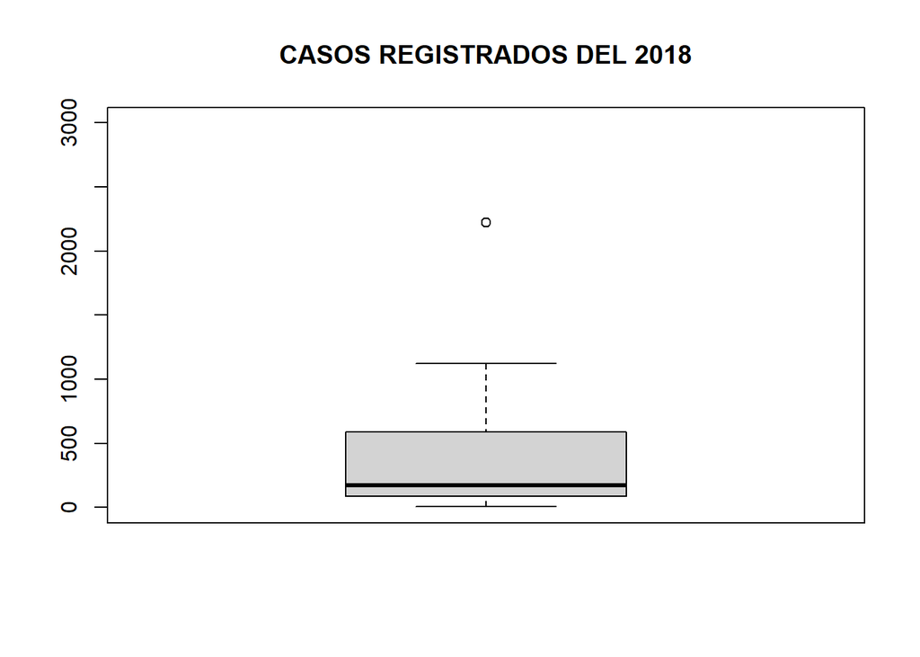

```r
boxplot(casos_ing_2018, ylim=c(0,3000),main = "CASOS REGISTRADOS DEL 2018")
```

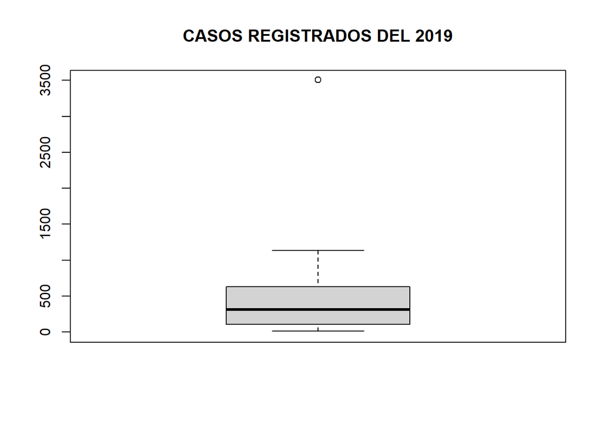

```r
boxplot(casos_ing_2019 , ylim=c(0,3500),main = "CASOS REGISTRADOS DEL 2019")
```

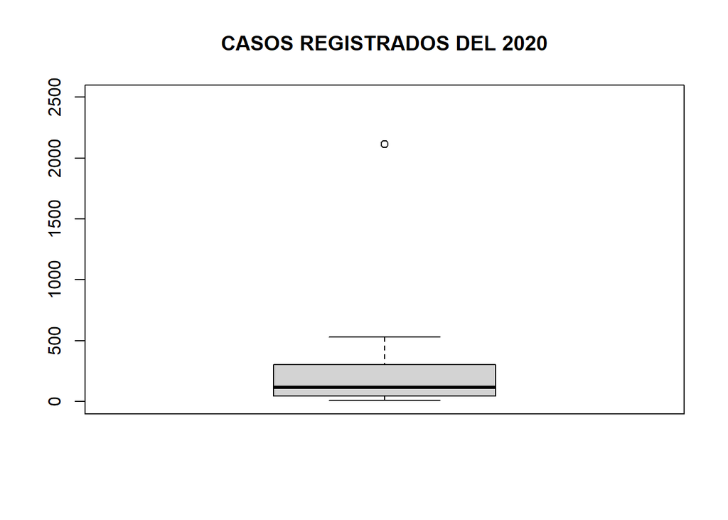

```r
boxplot(casos_ing_2020, ylim=c(0,2500),main = "CASOS REGISTRADOS DEL 2020")
```

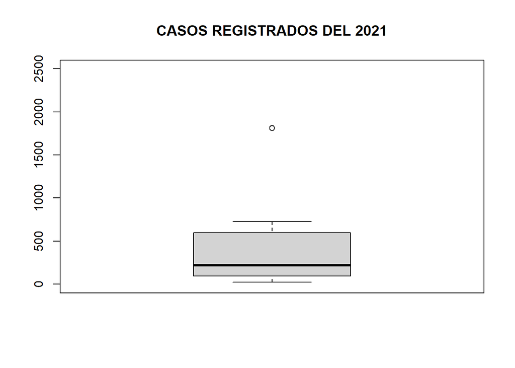

```r
boxplot(casos_ing_2021, ylim=c(0,2500),main = "CASOS REGISTRADOS DEL 2021")
```

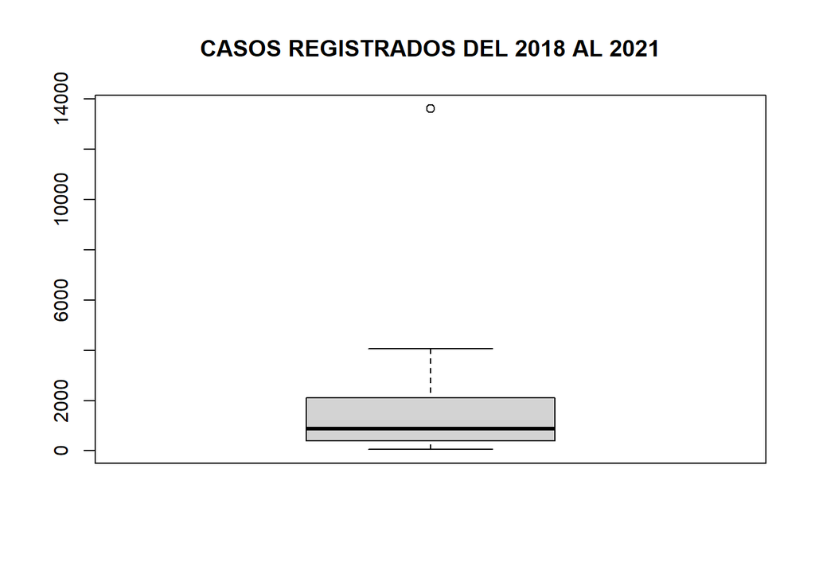

```r
boxplot(casos_ing_totales,main = "CASOS REGISTRADOS DEL 2018 AL 2021")
```

```r
DFT<- bind_rows(DFL_2018, DFL_2019, DFL_2020, DFL_2021)
```

### CASOS ATENDIDOS VS CASOS INGRESADOS DURANTE LOS AÑOS 2018-2021

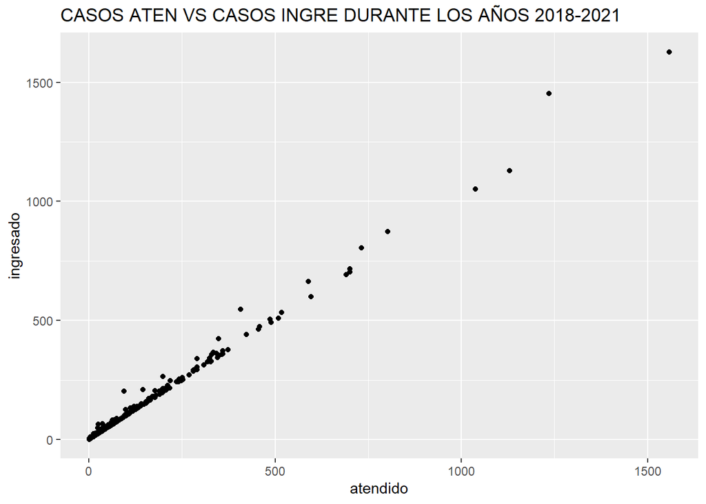

```r
ggplot(data=DFT) +
  geom_point(aes(atendido,ingresado),na.rm=TRUE, fill = "#003566")+ ggtitle("CASOS ATEN VS CASOS INGRE DURANTE LOS AÑOS 2018-2021")
```

### CASOS DE VIOLENCIA FAMILIAR REGISTRADOS POR REGIONES PARA CADA AÑO (2018, 2019, 2020 y 2021)

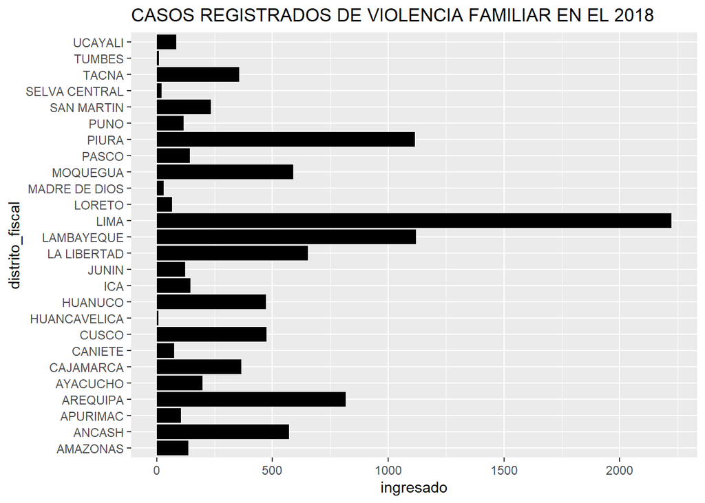

```r
ggplot(data=DFL_2018) +
  geom_col(aes(ingresado,distrito_fiscal), fill = "black",
)+ ggtitle("CASOS REGISTRADOS DE VIOLENCIA FAMILIAR EN EL 2018 ")
```

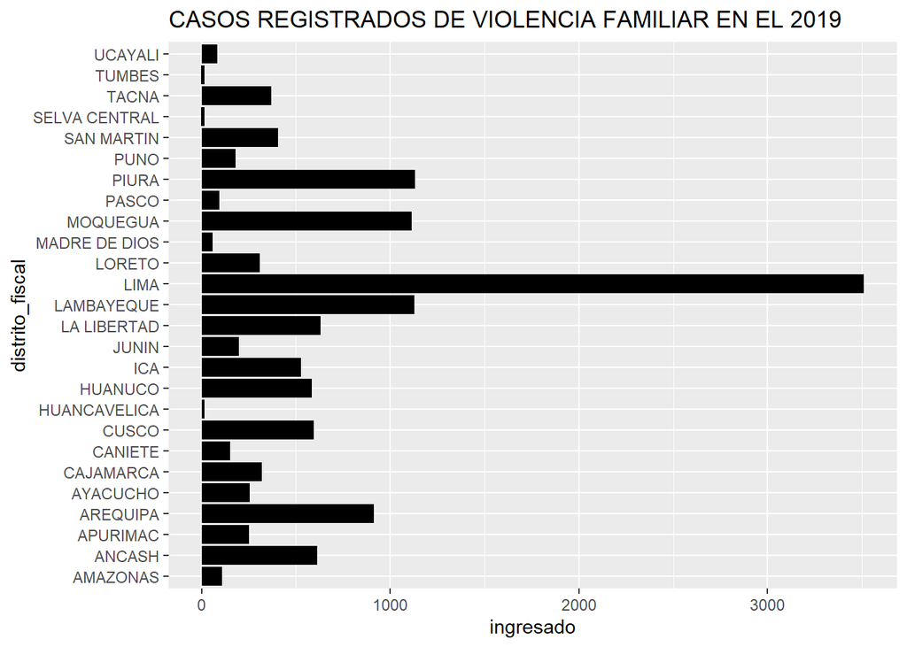

```r
ggplot(data=DFL_2019) +
  geom_col(aes(ingresado,distrito_fiscal), fill = "black",
)+ ggtitle("CASOS REGISTRADOS DE VIOLENCIA FAMILIAR EN EL 2019 ")
```

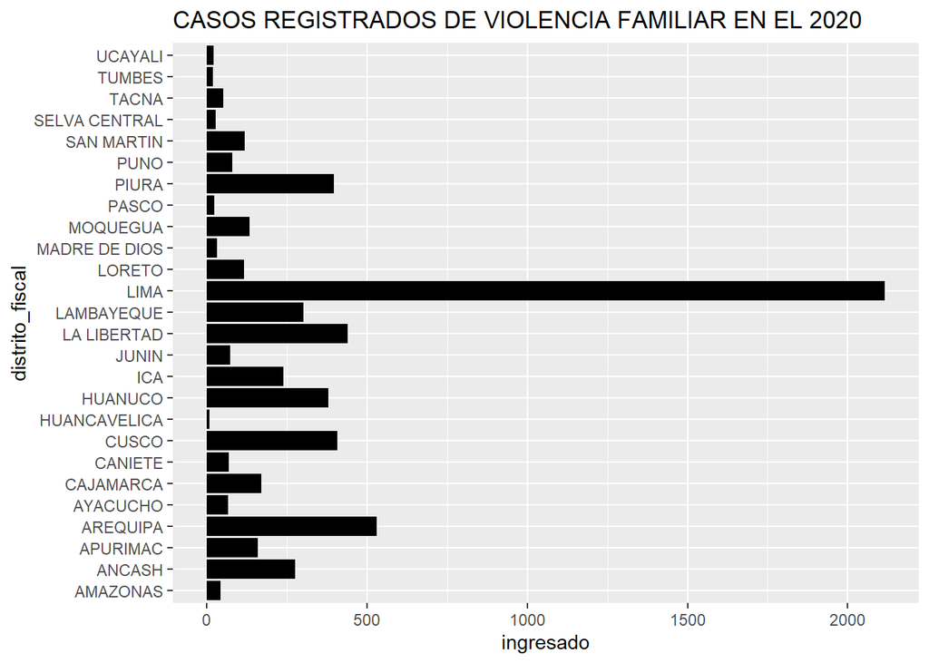

```r
ggplot(data=DFL_2020) +
  geom_col(aes(ingresado,distrito_fiscal), fill = "black",
)+ ggtitle("CASOS REGISTRADOS DE VIOLENCIA FAMILIAR EN EL 2020 ")
```

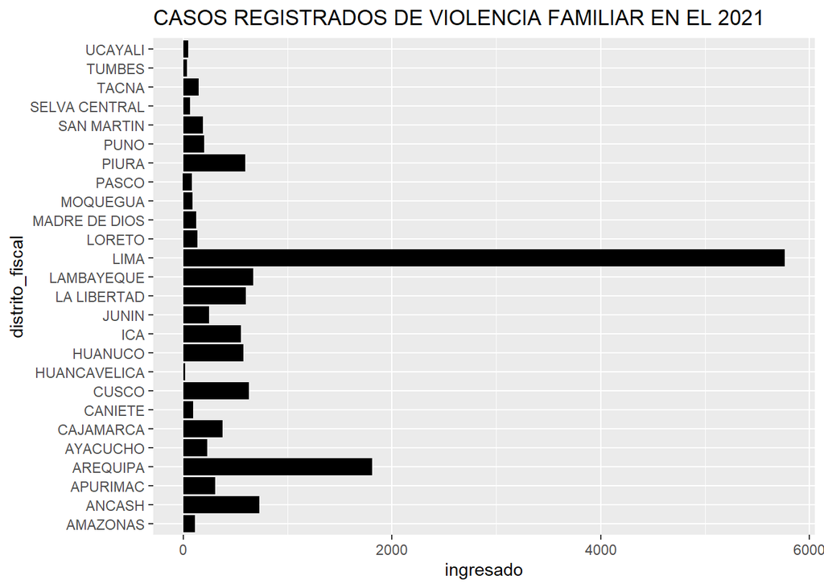

```r
ggplot(data=DFL_2021) +
  geom_col(aes(ingresado,distrito_fiscal), fill = "black",
)+ ggtitle("CASOS REGISTRADOS DE VIOLENCIA FAMILIAR EN EL 2021 ")
```

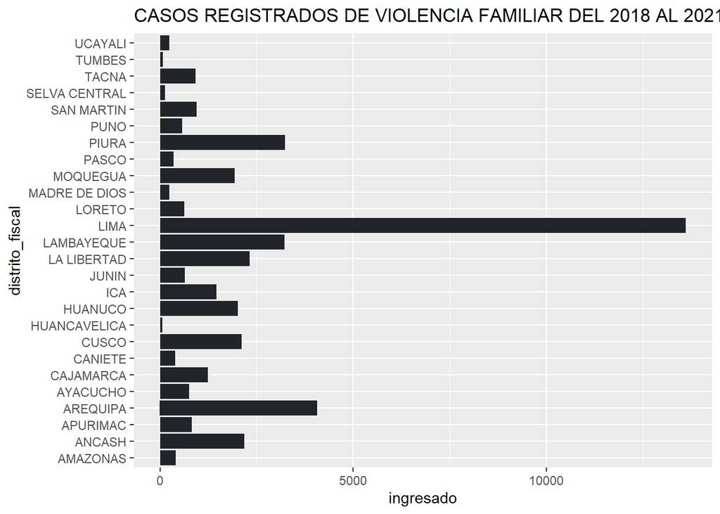

```r
ggplot(data=DFT) +
  geom_col(aes(ingresado,distrito_fiscal), fill = "#212529")+ ggtitle("CASOS REGISTRADOS DE VIOLENCIA FAMILIAR DEL 2018 AL 2021 ")
```

### CASOS DE VIOLENCIA FAMILIAR REGISTRADOS EN EL PERÚ PARA CADA AÑO (2018, 2019, 2020, 2021)

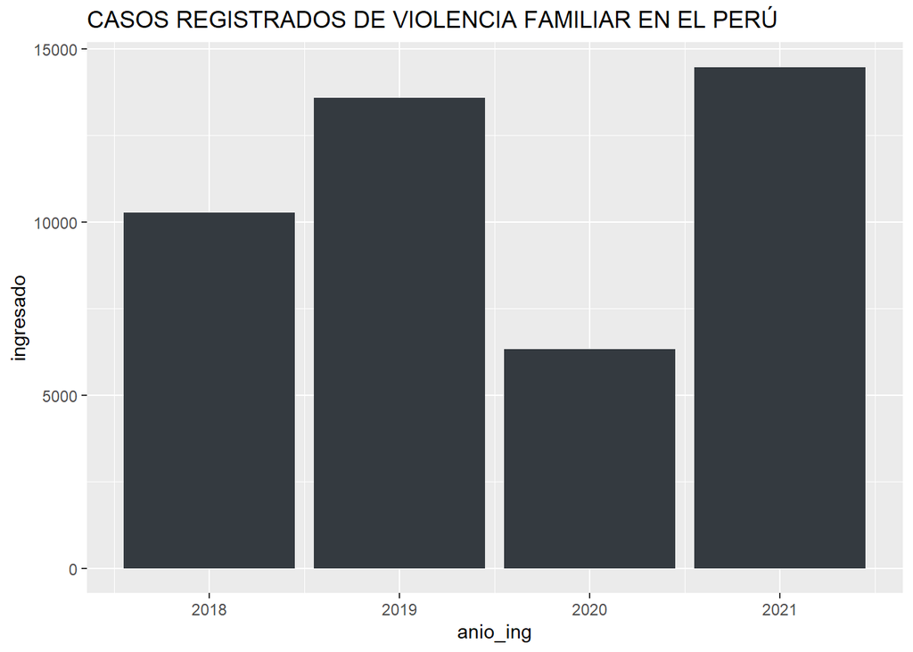

```r
ggplot(data=DFT) +
  geom_col(aes(anio_ing,ingresado), fill = "#343a40")+ ggtitle("CASOS REGISTRADOS DE VIOLENCIA FAMILIAR EN EL PERÚ ")
```

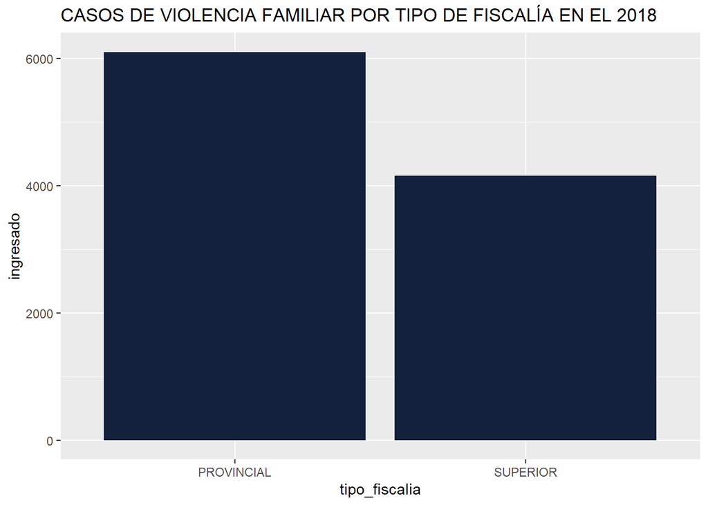

```r
ggplot(data=DFL_2018) +
  geom_col(aes(tipo_fiscalia,ingresado), fill = "#14213d")+ ggtitle("CASOS DE VIOLENCIA FAMILIAR POR TIPO DE FISCALÍA EN EL 2018 ")
```

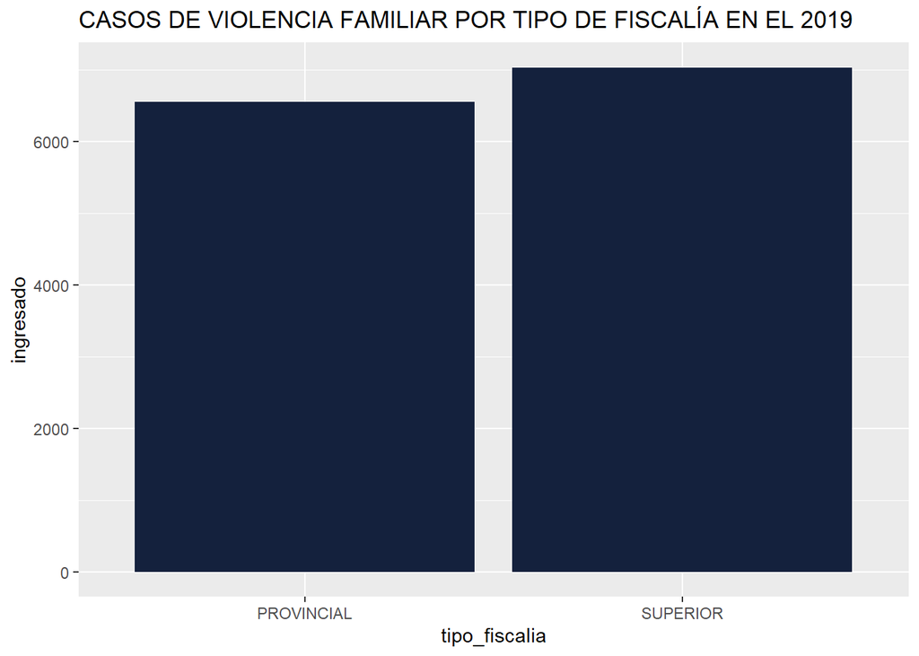

```r
ggplot(data=DFL_2019) +
  geom_col(aes(tipo_fiscalia,ingresado), fill = "#14213d")+ ggtitle("CASOS DE VIOLENCIA FAMILIAR POR TIPO DE FISCALÍA EN EL 2019 ")
```

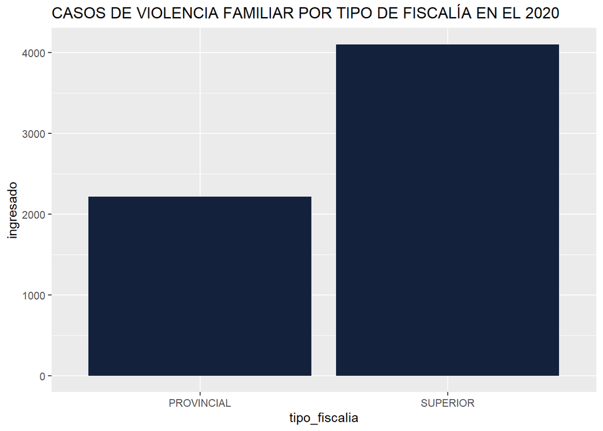

```r
ggplot(data=DFL_2020) +
  geom_col(aes(tipo_fiscalia,ingresado), fill = "#14213d")+ ggtitle("CASOS DE VIOLENCIA FAMILIAR POR TIPO DE FISCALÍA EN EL 2020 ")
```

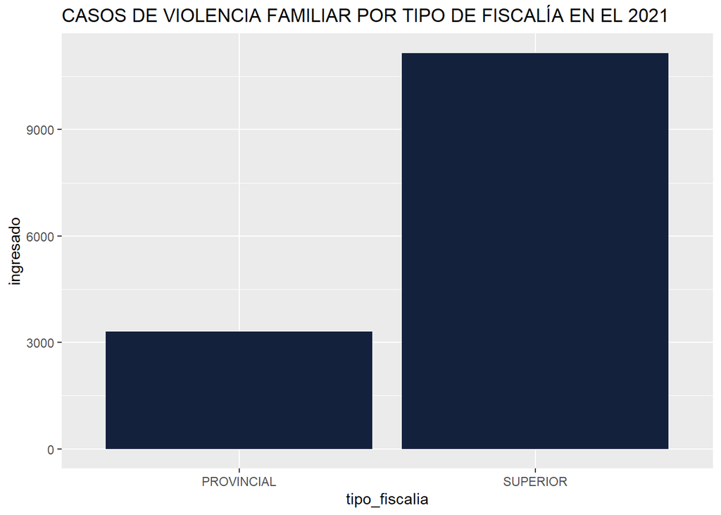

```r
ggplot(data=DFL_2021) +
  geom_col(aes(tipo_fiscalia,ingresado), fill = "#14213d")+ ggtitle("CASOS DE VIOLENCIA FAMILIAR POR TIPO DE FISCALÍA EN EL 2021")
```

### CASOS INGRESADOS DE VIOLENCIA FAMILIAR POR TIPO DE FISCALÍA

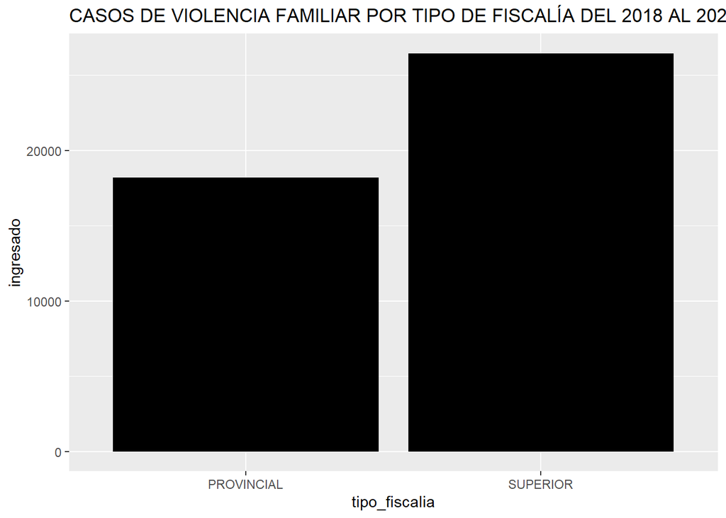

```r
ggplot(data=DFT) +
  geom_col(aes(tipo_fiscalia,ingresado), fill = "black")+ ggtitle("CASOS DE VIOLENCIA FAMILIAR POR TIPO DE FISCALÍA DEL 2018 AL 2021 ")
```

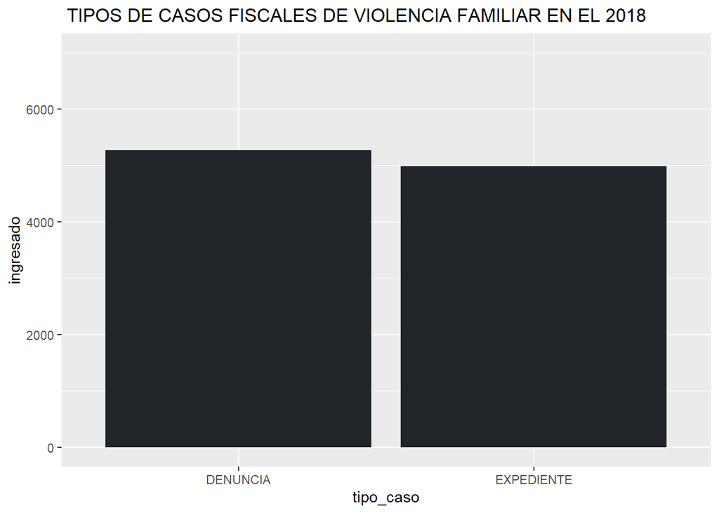

```r
ggplot(data=DFL_2018) +
  geom_col(aes(tipo_caso,ingresado), fill = "#212529"
) + scale_y_continuous(limits = c(0, 7000))+ ggtitle(" TIPOS DE CASOS FISCALES DE VIOLENCIA FAMILIAR EN EL 2018 ")
```

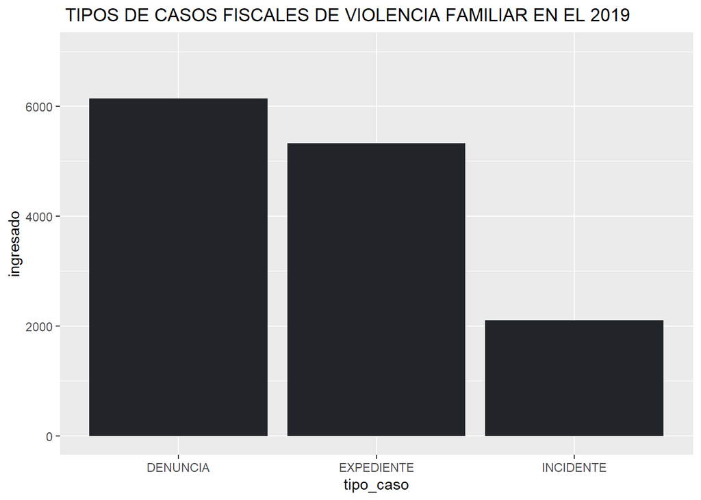

```r
ggplot(data=DFL_2019) +
  geom_col(aes(tipo_caso,ingresado), fill = "#212529") + scale_y_continuous(limits = c(0, 7000))+ ggtitle(" TIPOS DE CASOS FISCALES DE VIOLENCIA FAMILIAR EN EL 2019 ")
```

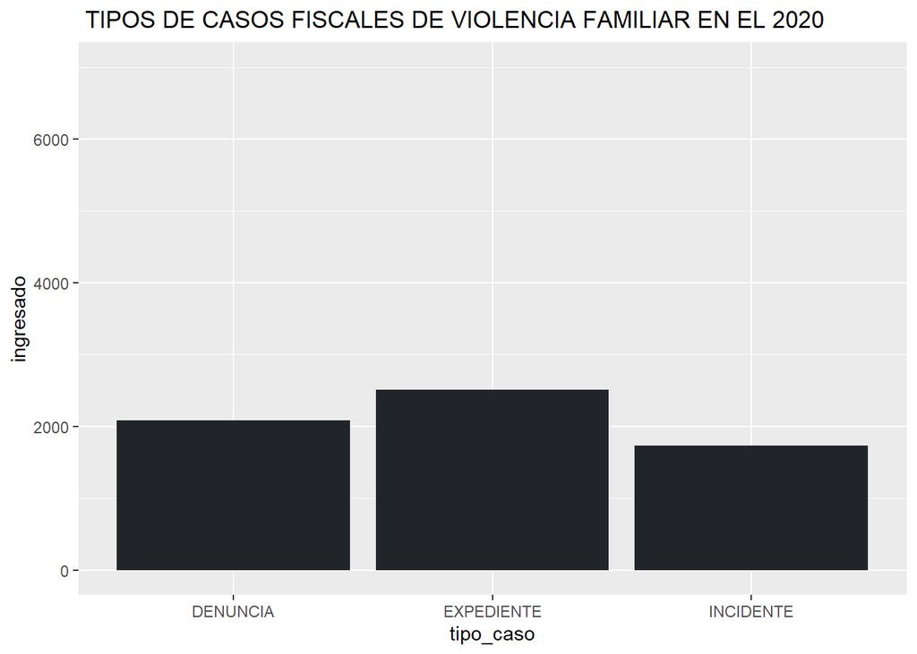

```r
ggplot(data=DFL_2020) +
  geom_col(aes(tipo_caso,ingresado), fill = "#212529") + scale_y_continuous(limits = c(0, 7000))+ ggtitle(" TIPOS DE CASOS FISCALES DE VIOLENCIA FAMILIAR EN EL 2020 ")
```

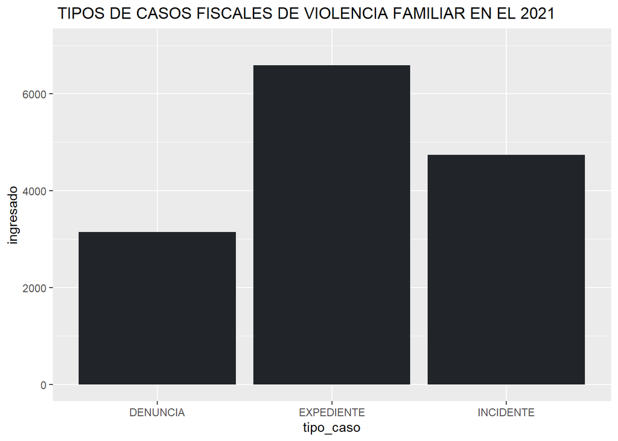

```r
ggplot(data=DFL_2021) +
  geom_col(aes(tipo_caso,ingresado), fill = "#212529") + scale_y_continuous(limits = c(0, 7000))+ ggtitle(" TIPOS DE CASOS FISCALES DE VIOLENCIA FAMILIAR EN EL 2021 ")
```

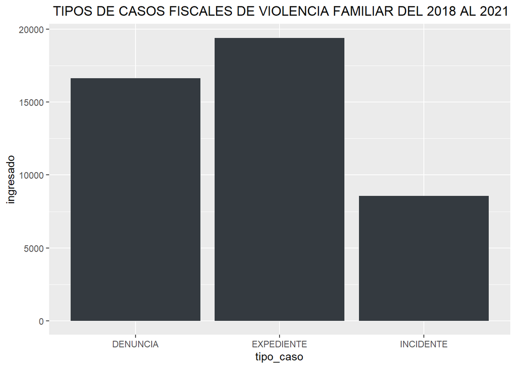

```r
ggplot(data=DFT) +
  geom_col(aes(tipo_caso,ingresado), fill = "#343a40") + ggtitle(" TIPOS DE CASOS FISCALES DE VIOLENCIA FAMILIAR DEL 2018 AL 2021")
```